# Ford-GoBike Data Exploration

## Preliminary Wrangling

This document explores a dataset containing the trip data of the fordgo bike

```python
# import all packages and set plots to be embedded inline
import numpy as np
import pandas as pd
import matplotlib.pyplot as plt
import seaborn as sb


%matplotlib inline
```

> Load in your dataset and describe its properties through the questions below. Try and motivate your exploration goals through this section.

```python
#read csv file
df = pd.read_csv('fordgobike-tripdata.csv')
```

```python
df.shape
```

```
(183412, 16)
```

```python
df.dtypes
```

```
duration_sec                 int64
start_time                  object
end_time                    object
start_station_id           float64
start_station_name          object
start_station_latitude     float64
start_station_longitude    float64
end_station_id             float64
end_station_name            object
end_station_latitude       float64
end_station_longitude      float64
bike_id                      int64
user_type                   object
member_birth_year          float64
member_gender               object
bike_share_for_all_trip     object
dtype: object
```

```python
df.head()
```

|  | duration_sec | start_time | end_time | start_station_id | start_station_name | start_station_latitude | start_station_longitude | end_station_id | end_station_name | end_station_latitude | end_station_longitude | bike_id | user_type | member_birth_year | member_gender | bike_share_for_all_trip |
| --- | --- | --- | --- | --- | --- | --- | --- | --- | --- | --- | --- | --- | --- | --- | --- | --- |
| 0 | 52185 | 2019-02-28 17:32:10.1450 | 2019-03-01 08:01:55.9750 | 21.0 | Montgomery St BART Station (Market St at 2nd St) | 37.789625 | -122.400811 | 13.0 | Commercial St at Montgomery St | 37.794231 | -122.402923 | 4902 | Customer | 1984.0 | Male | No |
| 1 | 42521 | 2019-02-28 18:53:21.7890 | 2019-03-01 06:42:03.0560 | 23.0 | The Embarcadero at Steuart St | 37.791464 | -122.391034 | 81.0 | Berry St at 4th St | 37.775880 | -122.393170 | 2535 | Customer | NaN | NaN | No |
| 2 | 61854 | 2019-02-28 12:13:13.2180 | 2019-03-01 05:24:08.1460 | 86.0 | Market St at Dolores St | 37.769305 | -122.426826 | 3.0 | Powell St BART Station (Market St at 4th St) | 37.786375 | -122.404904 | 5905 | Customer | 1972.0 | Male | No |
| 3 | 36490 | 2019-02-28 17:54:26.0100 | 2019-03-01 04:02:36.8420 | 375.0 | Grove St at Masonic Ave | 37.774836 | -122.446546 | 70.0 | Central Ave at Fell St | 37.773311 | -122.444293 | 6638 | Subscriber | 1989.0 | Other | No |
| 4 | 1585 | 2019-02-28 23:54:18.5490 | 2019-03-01 00:20:44.0740 | 7.0 | Frank H Ogawa Plaza | 37.804562 | -122.271738 | 222.0 | 10th Ave at E 15th St | 37.792714 | -122.248780 | 4898 | Subscriber | 1974.0 | Male | Yes |

```python
df.describe()
```

|  | duration_sec | start_station_id | start_station_latitude | start_station_longitude | end_station_id | end_station_latitude | end_station_longitude | bike_id | member_birth_year |
| --- | --- | --- | --- | --- | --- | --- | --- | --- | --- |
| count | 183412.000000 | 183215.000000 | 183412.000000 | 183412.000000 | 183215.000000 | 183412.000000 | 183412.000000 | 183412.000000 | 175147.000000 |
| mean | 726.078435 | 138.590427 | 37.771223 | -122.352664 | 136.249123 | 37.771427 | -122.352250 | 4472.906375 | 1984.806437 |
| std | 1794.389780 | 111.778864 | 0.099581 | 0.117097 | 111.515131 | 0.099490 | 0.116673 | 1664.383394 | 10.116689 |
| min | 61.000000 | 3.000000 | 37.317298 | -122.453704 | 3.000000 | 37.317298 | -122.453704 | 11.000000 | 1878.000000 |
| 25% | 325.000000 | 47.000000 | 37.770083 | -122.412408 | 44.000000 | 37.770407 | -122.411726 | 3777.000000 | 1980.000000 |
| 50% | 514.000000 | 104.000000 | 37.780760 | -122.398285 | 100.000000 | 37.781010 | -122.398279 | 4958.000000 | 1987.000000 |
| 75% | 796.000000 | 239.000000 | 37.797280 | -122.286533 | 235.000000 | 37.797320 | -122.288045 | 5502.000000 | 1992.000000 |
| max | 85444.000000 | 398.000000 | 37.880222 | -121.874119 | 398.000000 | 37.880222 | -121.874119 | 6645.000000 | 2001.000000 |

```python
##finding null values
df.info();
```

```
<class 'pandas.core.frame.DataFrame'>
RangeIndex: 183412 entries, 0 to 183411
Data columns (total 16 columns):
 #   Column                   Non-Null Count   Dtype
---  ------                   --------------   -----
 0   duration_sec             183412 non-null  int64
 1   start_time               183412 non-null  object
 2   end_time                 183412 non-null  object
 3   start_station_id         183215 non-null  float64
 4   start_station_name       183215 non-null  object
 5   start_station_latitude   183412 non-null  float64
 6   start_station_longitude  183412 non-null  float64
 7   end_station_id           183215 non-null  float64
 8   end_station_name         183215 non-null  object
 9   end_station_latitude     183412 non-null  float64
 10  end_station_longitude    183412 non-null  float64
 11  bike_id                  183412 non-null  int64
 12  user_type                183412 non-null  object
 13  member_birth_year        175147 non-null  float64
 14  member_gender            175147 non-null  object
 15  bike_share_for_all_trip  183412 non-null  object
dtypes: float64(7), int64(2), object(7)
memory usage: 22.4+ MB
```

```python
#removing null rows found in the info
df.dropna(axis=0,inplace=True)
```

Drop unused columns which are bike_share_for_all_trip not clear what it represent start and end station longitude and latitude

```python
df.drop(columns=['bike_share_for_all_trip'],inplace= True)
```

```python
# transform two features from string to date and time
df['start_time'] = pd.to_datetime(df.start_time)
df['end_time'] = pd.to_datetime(df.end_time)
```

```python
#create new column for months
df['Start_Month']=df['start_time'].dt.month
```

```python
#create new column for dayname
df['Day_Name']=df['start_time'].dt.day_name()
```

```python
df['duration_min']=df['duration_sec']/60
```

```python
df['Age']=2021-df['member_birth_year']
```

```python
## create Age_Group using age numbers to help in visualization
Age_Group_Labels=['Youth','Adults','Seniors']

Age_Group_Limits=[15,24,63,64]

df['Age_Group']=pd.cut(df['Age'],bins=Age_Group_Limits,labels=Age_Group_Labels,right=False)
```

```python
df.Age_Group.value_counts()
```

```
Adults     164001
Youth        7421
Seniors       517
Name: Age_Group, dtype: int64
```

```python
df.duration_min.describe()
```

```
count    174952.000000
mean         11.733379
std          27.370082
min           1.016667
25%           5.383333
50%           8.500000
75%          13.150000
max        1409.133333
Name: duration_min, dtype: float64
```

```python
Duration_conditions=[(df['duration_min']<5),
                     (df['duration_min']>=5) & (df['duration_min']<10),
           (df['duration_min']>=10) &(df['duration_min']<30),
           (df['duration_min']>=30) &(df['duration_min']<60),
           (df['duration_min']>=60)&(df['duration_min']<24),
           (df['duration_min']>=24)]

Duration_labels= ['Less Than 5 min','5 min to 10 min','10 min to 30 min','30+ min','1 hour or more','1 day or more']
df['Duration_Labels']=np.select(Duration_conditions,Duration_labels)
```

```python
df['Duration_Labels'].value_counts()
```

```
5 min to 10 min     66387
10 min to 30 min    64617
Less Than 5 min     37924
30+ min              4638
1 day or more        1386
Name: Duration_Labels, dtype: int64
```

```python
#drop unused column memvber birth year after replacing it with age
df.drop(columns='member_birth_year',inplace=True)
```

```python
#create function to get distance from longitude and latitude using

def Distance_Haversine(lon_start, lat_start, lat_end, lon_end):

    lon_start, lat_start, lat_end, lon_end = map(np.radians, [lon_start, lat_start, lat_end, lon_end])

    lon_diff = np.absolute(lon_end - lon_start)
    lat_diff = np.absolute(lat_end - lat_start)


    dist = 2 * np.arcsin(np.sqrt(np.sin(lat_diff/2.0)**2 + np.cos(lat_start) * np.cos(lat_end) * np.sin(lon_diff/2.0)**2 ))
    dist_km = (6367 * dist)
    return dist_km
```

```python
df['Distance'] =  Distance_Haversine(df['start_station_longitude'],df['start_station_latitude'],df['end_station_latitude'],df['end_station_longitude'])
```

```python
df.head()
```

|  | duration_sec | start_time | end_time | start_station_id | start_station_name | start_station_latitude | start_station_longitude | end_station_id | end_station_name | end_station_latitude | ... | bike_id | user_type | member_gender | Start_Month | Day_Name | duration_min | Age | Age_Group | Duration_Labels | Distance |
| --- | --- | --- | --- | --- | --- | --- | --- | --- | --- | --- | --- | --- | --- | --- | --- | --- | --- | --- | --- | --- | --- |
| 0 | 52185 | 2019-02-28 17:32:10.145 | 2019-03-01 08:01:55.975 | 21.0 | Montgomery St BART Station (Market St at 2nd St) | 37.789625 | -122.400811 | 13.0 | Commercial St at Montgomery St | 37.794231 | ... | 4902 | Customer | Male | 2 | Thursday | 869.750000 | 37.0 | Adults | 1 day or more | 0.544367 |
| 2 | 61854 | 2019-02-28 12:13:13.218 | 2019-03-01 05:24:08.146 | 86.0 | Market St at Dolores St | 37.769305 | -122.426826 | 3.0 | Powell St BART Station (Market St at 4th St) | 37.786375 | ... | 5905 | Customer | Male | 2 | Thursday | 1030.900000 | 49.0 | Adults | 1 day or more | 2.702847 |
| 3 | 36490 | 2019-02-28 17:54:26.010 | 2019-03-01 04:02:36.842 | 375.0 | Grove St at Masonic Ave | 37.774836 | -122.446546 | 70.0 | Central Ave at Fell St | 37.773311 | ... | 6638 | Subscriber | Other | 2 | Thursday | 608.166667 | 32.0 | Adults | 1 day or more | 0.260575 |
| 4 | 1585 | 2019-02-28 23:54:18.549 | 2019-03-01 00:20:44.074 | 7.0 | Frank H Ogawa Plaza | 37.804562 | -122.271738 | 222.0 | 10th Ave at E 15th St | 37.792714 | ... | 4898 | Subscriber | Male | 2 | Thursday | 26.416667 | 47.0 | Adults | 10 min to 30 min | 2.407789 |
| 5 | 1793 | 2019-02-28 23:49:58.632 | 2019-03-01 00:19:51.760 | 93.0 | 4th St at Mission Bay Blvd S | 37.770407 | -122.391198 | 323.0 | Broadway at Kearny | 37.798014 | ... | 5200 | Subscriber | Male | 2 | Thursday | 29.883333 | 62.0 | Adults | 10 min to 30 min | 3.330111 |

5 rows × 21 columns

### Summary Data Preliminary Wrangling

1) transform duration sec to duration min to minimize the diffrence between values and help in making Duration Labels

2) Create Duration_Labels feature which represent a categorical representation of time into 5 categorize which enhancevisualizatoon

3) Use Start and End Station Longitude and Latitude to get Distance covered by users per trip

4) Create Age variable from member birth_year

### What is/are the main feature(s) of interest in your dataset?

The feature of main intrest is the duration_min and Duration_Labels feature and duration label feature and how they are affected by other features

### What features in the dataset do you think will help support your investigation into your feature(s) of interest?

The supporting features are the Distance, gender, Age, finaly the user type

## Univariate Exploration

> In this section, investigate distributions of individual variables. If you see unusual points or outliers, take a deeper look to clean things up and prepare yourself to look at relationships between variables.

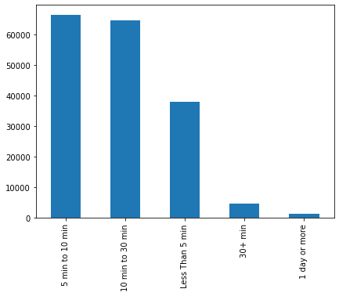

```python
plt.figure(figsize=(15,5));
plt.subplot(1,2,1);

duration_label_count=df['Duration_Labels'].value_counts()

duration_label_count.plot.bar();
```

This help us know which region of duration has larger value which is region between 1 min and 30 min so we adjust our data to meet this specification

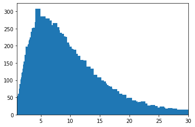

```python
plt.bar(df.duration_min.value_counts().index,df.duration_min.value_counts().values);
plt.xlim(1,30); # using limit that we deduced from the duration labels
```

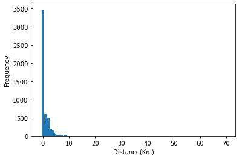

```python
distance_count=df.Distance.value_counts();

plt.bar(distance_count.index,distance_count.values);


plt.ylabel('Frequency');

plt.xlabel('Distance(Km)');
```

After the visualization and looking at Distance variable it came clear that Distance varies between 0 and 9 km

```python
df.Distance.describe()
```

```
count    174952.000000
mean          1.688988
std           1.096268
min           0.000000
25%           0.909872
50%           1.428932
75%           2.222614
max          69.425625
Name: Distance, dtype: float64
```

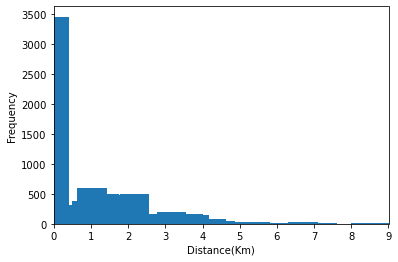

```python
distance_count=df.Distance.value_counts();

plt.bar(distance_count.index,distance_count.values);
plt.ylabel('Frequency');

plt.xlabel('Distance(Km)');

plt.xlim(0,9);
```

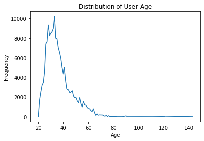

```python
df['Age'].value_counts().sort_index().plot.line()
plt.xlabel('Age')
plt.ylabel('Frequency')
plt.title('Distribution of User Age')
plt.show()
```

this show that the age of the dataset falls in region between 25 - 40 and maximum at 35

```python
n_gender   = df['member_gender'].value_counts().sum()

gender_order= df['member_gender'].value_counts().index

max_gender_count   =  df['member_gender'].value_counts()[0]

genderr=df['member_gender'].value_counts()


max_props_gender=max_gender_count/n_gender
```

```python
tick_props = np.arange(0, max_props_gender, 0.2)
tick_names = ['{:0.2f}'.format(v) for v in tick_props]
```

```python
n_user_type   = df['user_type'].value_counts().sum()

user_type_order= df['user_type'].value_counts().index

max_user_type_count   =  df['user_type'].value_counts()[0]

user_typee = df["user_type"].value_counts()


max_props_user=max_user_type_count/n_user_type
```

```python
#this is used to change the scale of the y-axis and put correspondece percentage
tick_props_user = np.arange(0, max_props_user, 0.2)
tick_names = ['{:0.2f}'.format(_) for _ in tick_props]
```

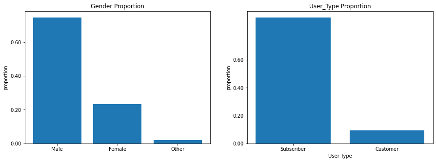

```python
plt.figure(figsize=(15,5))
plt.subplot(1,2,1);
plt.bar(gender_order, genderr.values)

plt.yticks(tick_props * n_gender, tick_names)
plt.ylabel('proportion');
plt.title('Gender Proportion');

plt.subplot(1,2,2);
plt.bar(user_type_order, user_typee.values)


plt.yticks(tick_props * n_user_type , tick_names)
plt.ylabel('proportion');
plt.xlabel("User Type")
plt.title('User_Type Proportion');
```

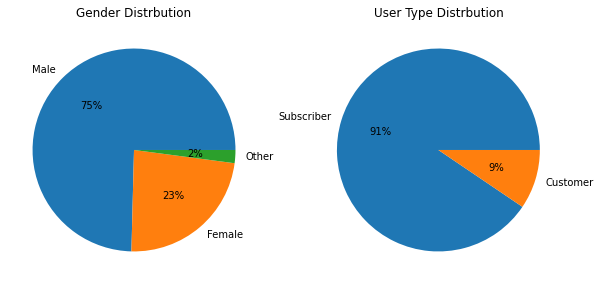

```python
plt.figure(figsize=(15,5))
plt.subplot(1,2,1);
genderr.plot.pie(figsize=(10,10), autopct='%1.0f%%');
plt.title('Gender Distrbution')
plt.ylabel('')
plt.subplot(1,2,2);
user_typee.plot.pie(figsize=(10,10), autopct='%1.0f%%');
plt.title('User Type Distrbution')
plt.ylabel('')
plt.show()
```

Most of the dataset collected was from male It is clear that dataset contain alot more subscribers than customers

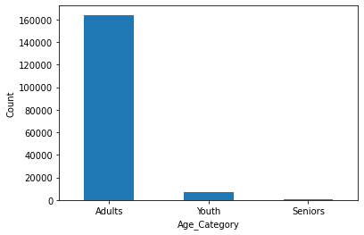

```python
df.Age_Group.value_counts().plot.bar();
plt.xticks(rotation=360);
plt.xlabel('Age_Category');
plt.ylabel('Count');
```

Most users of dataset are adults

### Discuss the distribution(s) of your variable(s) of interest. Were there any unusual points? Did you need to perform any transformations?

1) Duration: Duration was presented better using duration labels variable created in wrangling process which helped having better understanding where the duration points lie and how to measure them there was alot of outliers points which was avoided by setting correct limit measured from duration labels which has the most percentage of data.

2) Distance: Distance also had alot of outliers which was observed from the graph after looking closer to the distance variable created and was avoided by setting correct limit that had most of the percentage of data

5) User Type : from this feature we deduced that 91 percent of the people who use variable are Subscribers while 9 percent are customers

6) Gender: 75 percent of users were male, 23 percent female, 2 percent are others

### Of the features you investigated, were there any unusual distributions? Did you perform any operations on the data to tidy, adjust, or change the form of the data? If so, why did you do this?

age column was added from the member birth year column duration was changed from sec to min then duration labels feature was created which is used to have better visualization to time than old visualization

## Bivariate Exploration

> In this section, investigate relationships between pairs of variables in your data. Make sure the variables that you cover here have been introduced in some fashion in the previous section (univariate exploration).

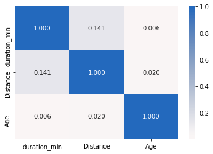

```python
sb.heatmap(df[['duration_min','Distance','Age']].corr(), annot = True, fmt = '.3f',
           cmap = 'vlag_r', center = 0);
```

realtion between distance and duration min

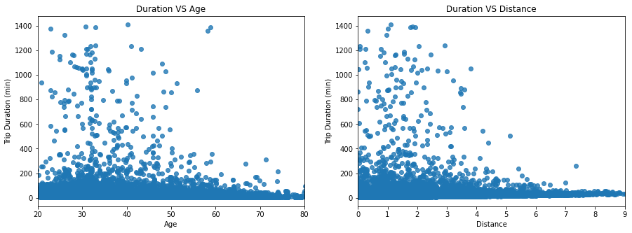

```python
plt.figure(figsize=(15,5))
plt.subplot(1,2,1);

sb.regplot(data = df, x = 'Age', y = 'duration_min', truncate=False, x_jitter=0.3);
plt.xlabel('Age')
plt.xlim(20, 80)
plt.ylabel('Trip Duration (min)')
plt.title('Duration VS Age')


plt.subplot(1,2,2);


sb.regplot(data = df, x = 'Distance', y = 'duration_min', truncate=False, x_jitter=0.3,fit_reg=False);
plt.xlabel('Distance')
plt.ylabel('Trip Duration (min)')
plt.title('Duration VS Distance');
plt.xlim(0,9);
```

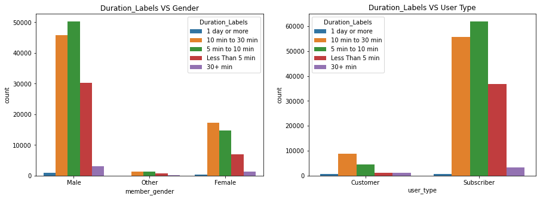

```python
plt.figure(figsize=(15,5))
plt.subplot(1,2,1);
sb.countplot(data=df, hue='Duration_Labels', x='member_gender');
plt.title('Duration_Labels VS Gender');
plt.subplot(1,2,2);

sb.countplot(data=df, hue='Duration_Labels', x='user_type');
plt.title('Duration_Labels VS User Type');
```

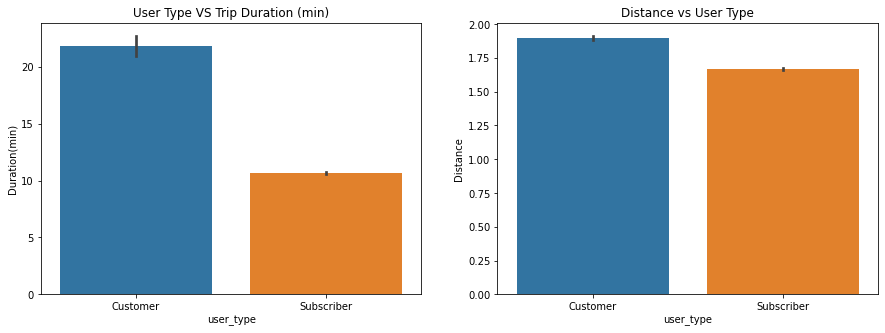

```python
plt.figure(figsize=(15,5))
plt.subplot(1,2,1);
sb.barplot(data=df,y='duration_min',x='user_type');
plt.title('User Type VS Trip Duration (min)');
plt.ylabel("Duration(min)");
plt.subplot(1,2,2);
sb.barplot(data=df,y='Distance',x='user_type');
plt.title('Distance vs User Type');
```

customer tend to have more duration take than subscribers and wide range of subscribers take less than 10 min per ride

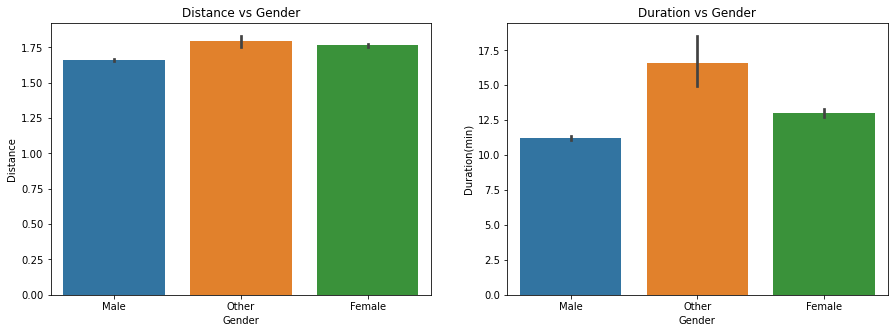

```python
plt.figure(figsize=(15,5))
plt.subplot(1,2,1);
sb.barplot(data=df,y='Distance',x='member_gender');
plt.title('Distance vs Gender');

plt.xlabel('Gender');

plt.subplot(1,2,2);

sb.barplot(data=df,y='duration_min',x='member_gender');
plt.title('Duration vs Gender');

plt.ylabel('Duration(min)')
plt.xlabel('Gender');
```

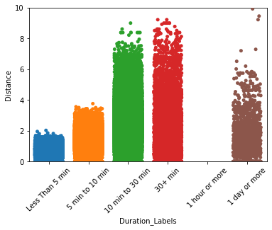

```python
sb.stripplot(data=df, x='Duration_Labels',y='Distance',jitter=0.35,dodge=True,order=['Less Than 5 min','5 min to 10 min','10 min to 30 min','30+ min','1 hour or more','1 day or more']);
plt.xticks(rotation=45);
plt.ylim(0,10);
```

### Did you observe any interesting relationships between the other features (not the main feature(s) of interest)?

on a very small scale customersfemale and other gender type tend to cover more distance than male and customers tend to cover more distance than subscribers

## Multivariate Exploration

> Create plots of three or more variables to investigate your data even further. Make sure that your investigations are justified, and follow from your work in the previous sections.

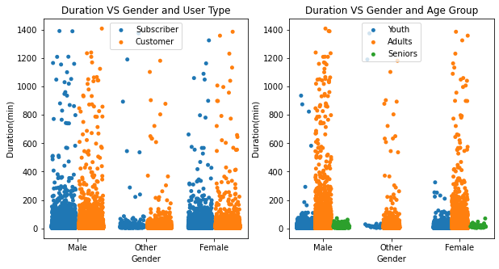

```python
plt.figure(figsize=(10,5))
plt.subplot(1,2,1);
sb.stripplot(data=df, x='member_gender',y='duration_min',hue='user_type',jitter=0.35,dodge=True)
plt.xlabel('Gender')
plt.ylabel('Duration(min)');



plt.legend(['Subscriber','Customer']);

plt.title('Duration VS Gender and User Type');
plt.subplot(1,2,2);

sb.stripplot(data=df, x='member_gender',y='duration_min',hue='Age_Group',jitter=0.35,dodge=True)
plt.xlabel('Gender')
plt.ylabel('Duration(min)');
plt.legend(['Youth','Adults','Seniors']);

plt.title('Duration VS Gender and Age Group');
```

it is clear from this visualization that there is no pattern and that data is equaly distrbuted

Same Visualization but after adding time limitage of 1 -30 min

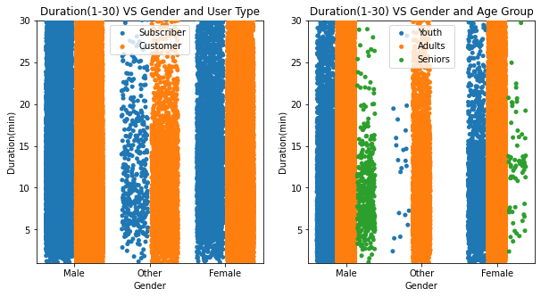

```python
plt.figure(figsize=(10,5))
plt.subplot(1,2,1);
sb.stripplot(data=df, x='member_gender',y='duration_min',hue='user_type',jitter=0.35,dodge=True)
plt.xlabel('Gender')
plt.ylabel('Duration(min)');


plt.ylim(1,30)


plt.legend(['Subscriber','Customer']);

plt.title('Duration(1-30) VS Gender and User Type');
plt.subplot(1,2,2);

sb.stripplot(data=df, x='member_gender',y='duration_min',hue='Age_Group',jitter=0.35,dodge=True)
plt.xlabel('Gender')
plt.ylabel('Duration(min)');
plt.legend(['Youth','Adults','Seniors']);
plt.ylim(1,30)

plt.title('Duration(1-30) VS Gender and Age Group');
```

The visualization show that there is equal distrbution of user type across all genders

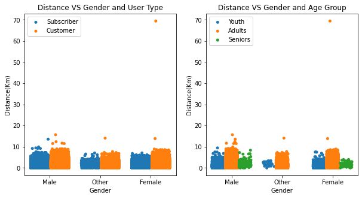

```python
plt.figure(figsize=(10,5))
plt.subplot(1,2,1);
sb.stripplot(data=df, x='member_gender',y='Distance',hue='user_type',jitter=0.35,dodge=True)
plt.xlabel('Gender')
plt.ylabel('Distance(Km)');



plt.legend(['Subscriber','Customer']);

plt.title('Distance VS Gender and User Type');
plt.subplot(1,2,2);

sb.stripplot(data=df, x='member_gender',y='Distance',hue='Age_Group',jitter=0.35,dodge=True)
plt.xlabel('Gender')
plt.ylabel('Distance(Km)');
plt.legend(['Youth','Adults','Seniors']);

plt.title('Distance VS Gender and Age Group');
```

Using Limit of Distance which was 0-10

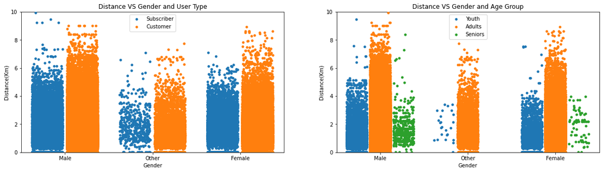

```python
plt.figure(figsize=(20,5))
plt.subplot(1,2,1);
sb.stripplot(data=df, x='member_gender',y='Distance',hue='user_type',jitter=0.35,dodge=True)
plt.xlabel('Gender')
plt.ylabel('Distance(Km)');

plt.ylim(0,10)

plt.legend(['Subscriber','Customer']);

plt.title('Distance VS Gender and User Type');
plt.subplot(1,2,2);

sb.stripplot(data=df, x='member_gender',y='Distance',hue='Age_Group',jitter=0.35,dodge=True)
plt.xlabel('Gender')
plt.ylabel('Distance(Km)');
plt.legend(['Youth','Adults','Seniors']);

plt.ylim(0,10)

plt.title('Distance VS Gender and Age Group');
```

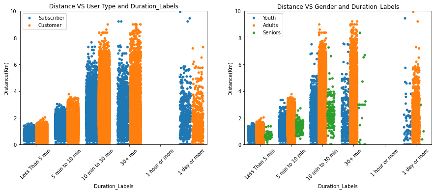

```python
plt.figure(figsize=(15,5))
plt.subplot(1,2,1);

sb.stripplot(data=df, x='Duration_Labels',y='Distance',hue='user_type',jitter=0.35,dodge=True,order=['Less Than 5 min','5 min to 10 min','10 min to 30 min','30+ min','1 hour or more','1 day or more'])
plt.xlabel('Duration_Labels')
plt.ylabel('Distance(Km)');
plt.legend(['Subscriber','Customer']);
plt.xticks(rotation=45);

plt.ylim(0,10)

plt.title('Distance VS User Type and Duration_Labels');



plt.subplot(1,2,2);

sb.stripplot(data=df, x='Duration_Labels',y='Distance',hue='Age_Group',jitter=0.35,dodge=True,order=['Less Than 5 min','5 min to 10 min','10 min to 30 min','30+ min','1 hour or more','1 day or more'])
plt.xlabel('Duration_Labels')
plt.ylabel('Distance(Km)');
plt.legend(['Youth','Adults','Seniors']);
plt.xticks(rotation=45);

plt.ylim(0,10)

plt.title('Distance VS Gender and Duration_Labels');
```

> At the end of your report, make sure that you export the notebook as an html file from the `File > Download as... > HTML` menu. Make sure you keep track of where the exported file goes, so you can put it in the same folder as this notebook for project submission. Also, make sure you remove all of the quote-formatted guide notes like this one before you finish your report!